# Solar Panel Business Case

Rob Carnell

2025-07-02

## Forecast

Goal: Determine which, if any, of the solar quotes have a positive net present value based on historical usage data.

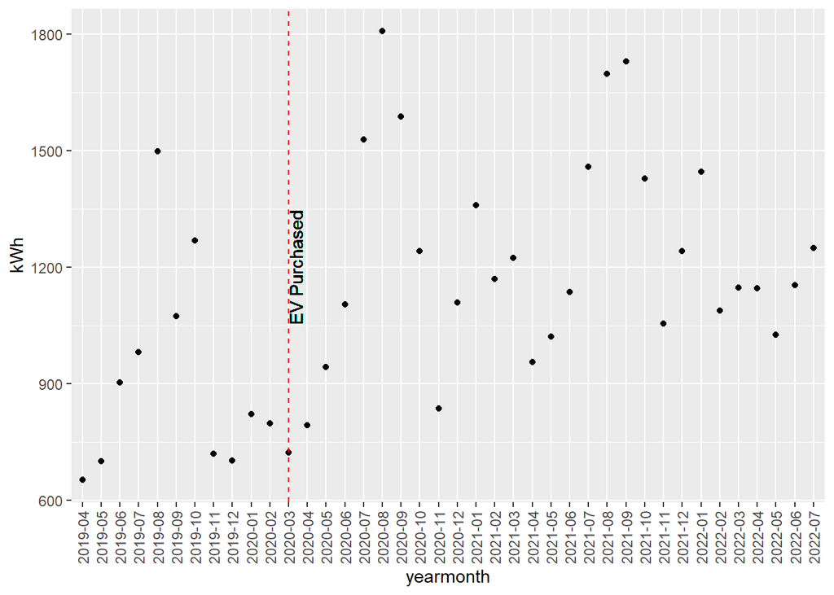

- Usage per year (KWh): 15,286
- Transmission Cost per year: $463.71
- Distribution Cost per year: $631.15
- Customer Cost per year: $120
- Generation Cost per year: $1,205.15
- Bill Total: $2,420.02

### Options for Solar Systems

- Blue Raven:
  - Panels: 32
  - W per panel: 400
  - Total Generation (KW): 12.8 = 32*400
  - Yearly (KWh): 13,380
  - Total Cost: $46,341
  - Tax Break: $12,049
  - Net Cost: $34,292
  - 25 yr Efficiency: 92%
- EcoHouse
  - Panels: 39
  - W per panel: 360
  - Total Generation (KW): 14.04 = 39*360
  - Yearly (KWh): 15,453
  - Total Cost: $42,500
  - Tax Break: $12,750
  - Net Cost: $29,750
  - 25 yr Efficiency: 80%

### Assumptions:

- Energy Inflation: 4%
- Overall Inflation: 2%

### Forecast Timeseries

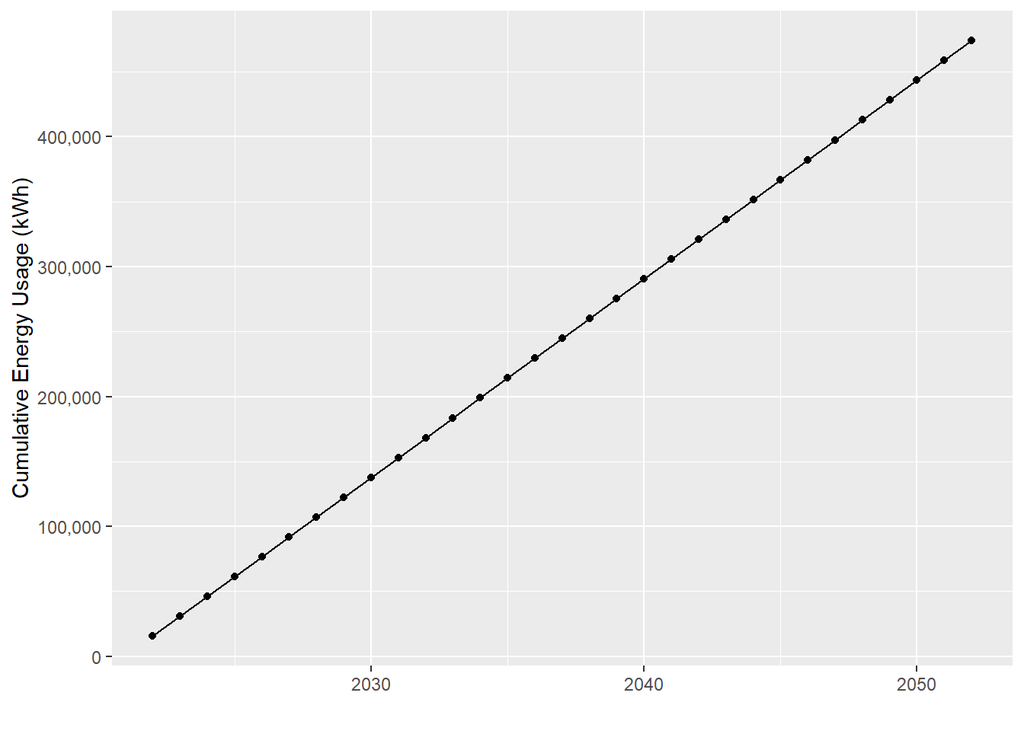

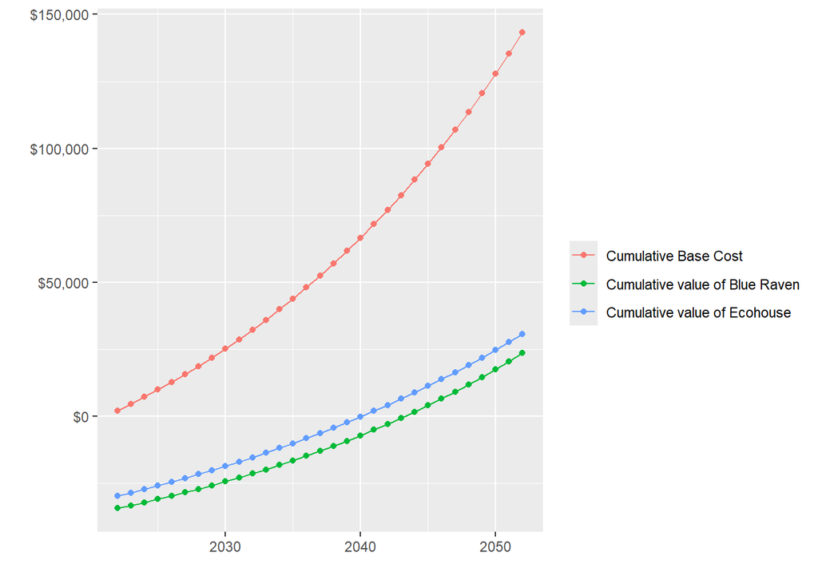

### Calculate 25 yr Net Present Value

- Blue Raven: -1748.9380501
- EcoHouse: 5069.9469028

## Temperature vs Energy Forecast

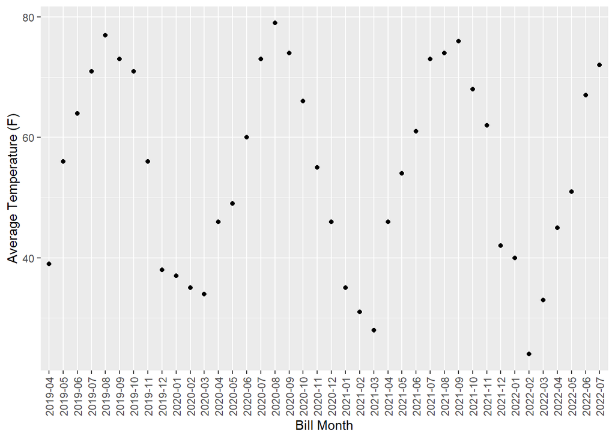

### Energy Usage vs Temperature

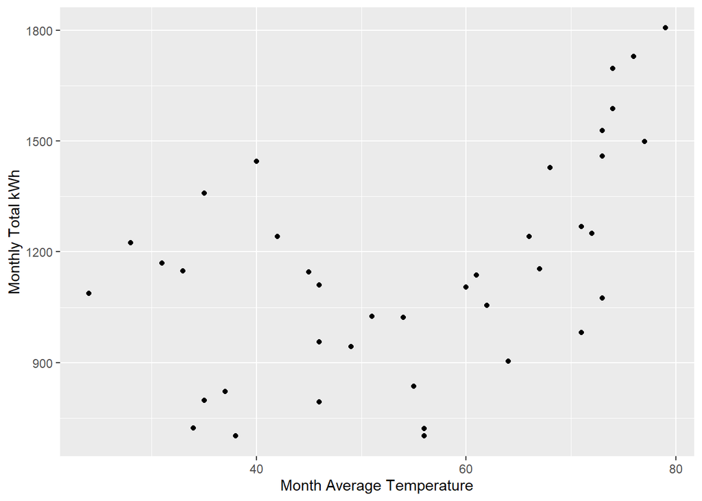

### Energy Usage per Day vs Temperature

Energy usage per day should remove some variability due to months of different lengths

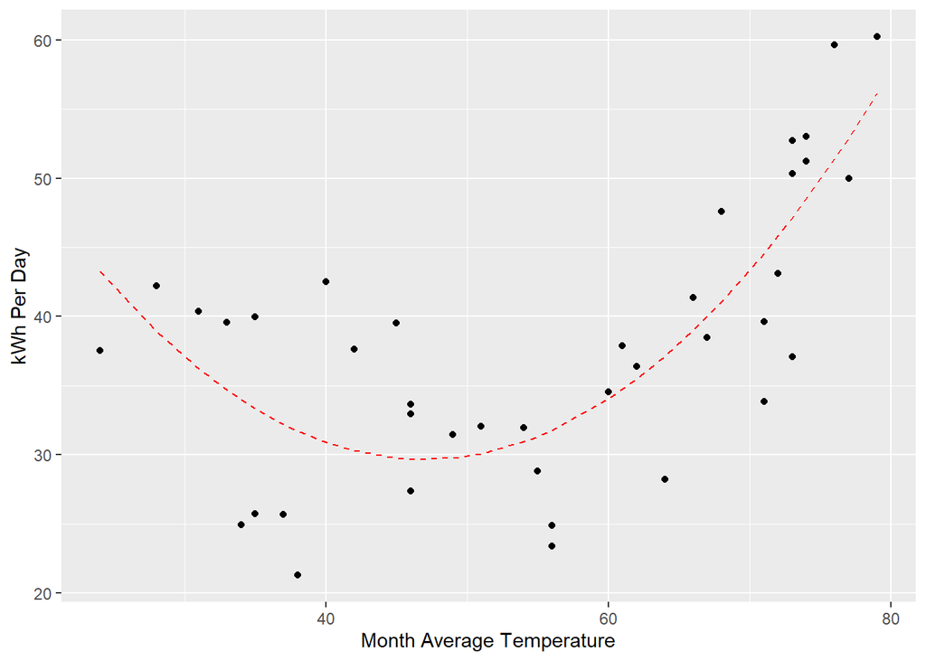

### Fit

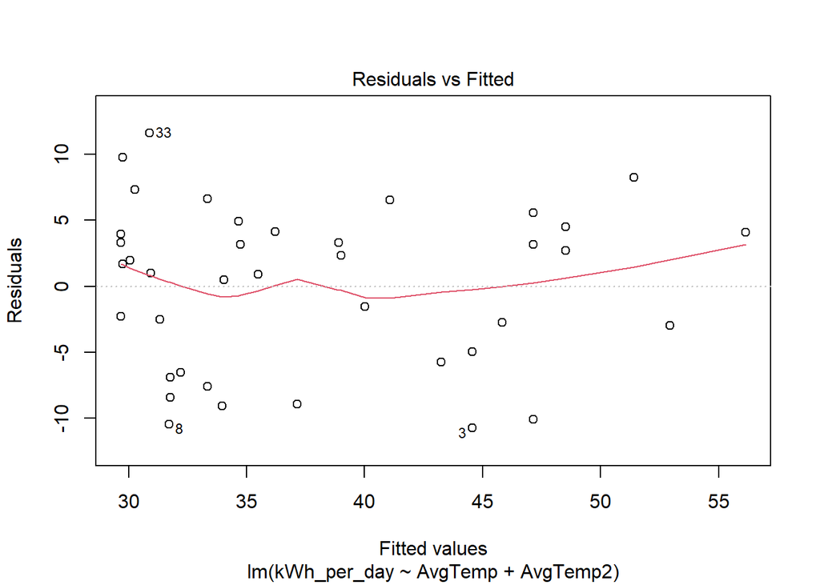

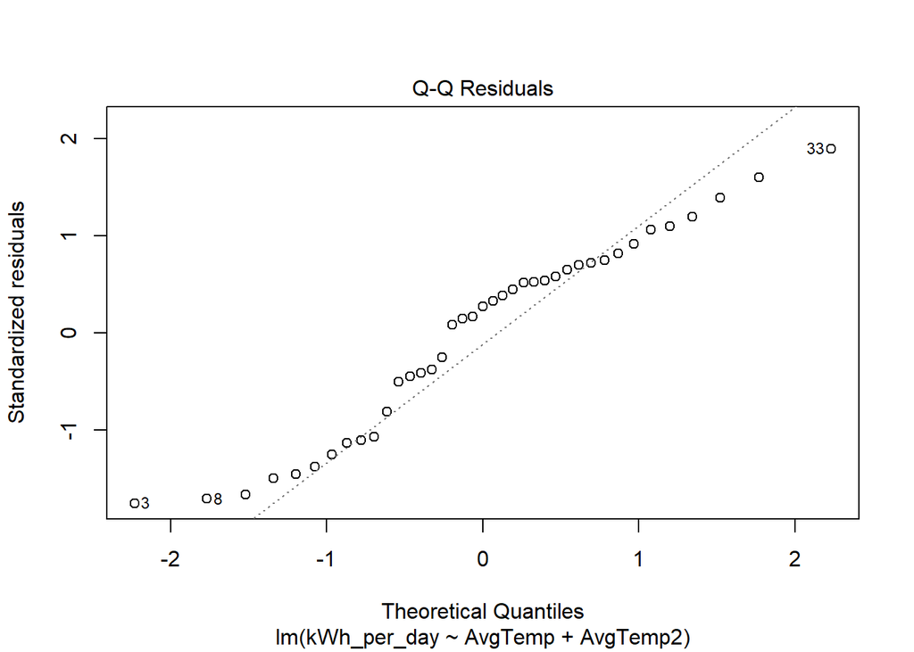

## Actuals and Forecast

#### Actual Temp since Installation

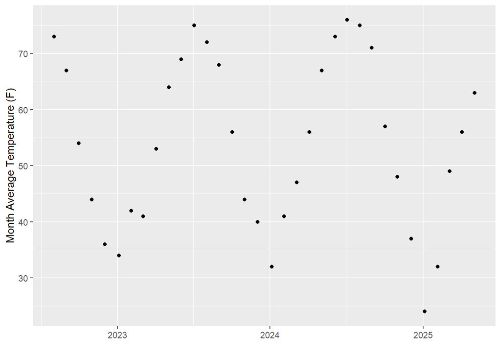

#### Actual Usage since Installation

- Total Demand - The amount of power used in the home
- From Grid - The amount of power needed by the house from the grid
- To Grid - The amount of power supplied by the solar panels to the grid
- Solar Production - The amount of power created by the solar panels

Solar Production + From Grid = Actual Total Demand + To Grid

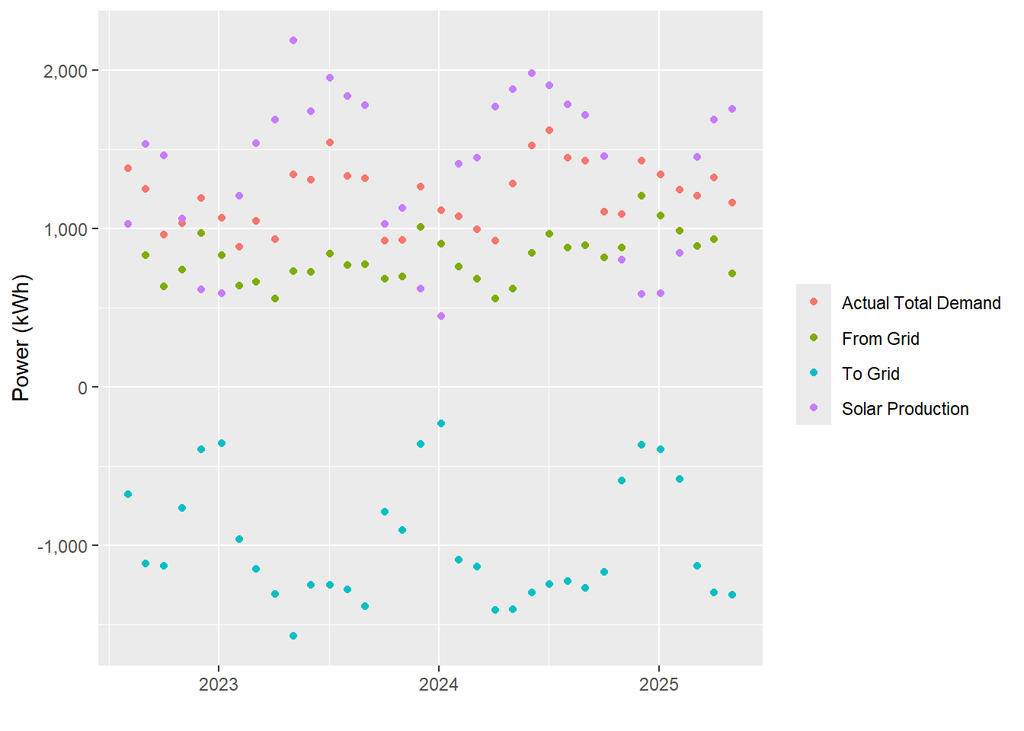

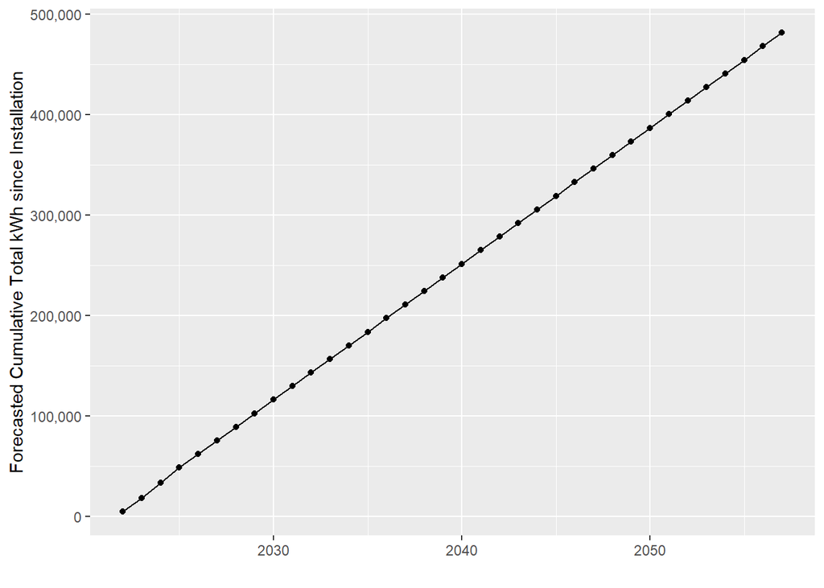

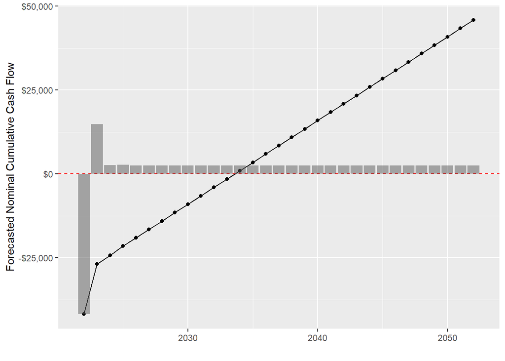

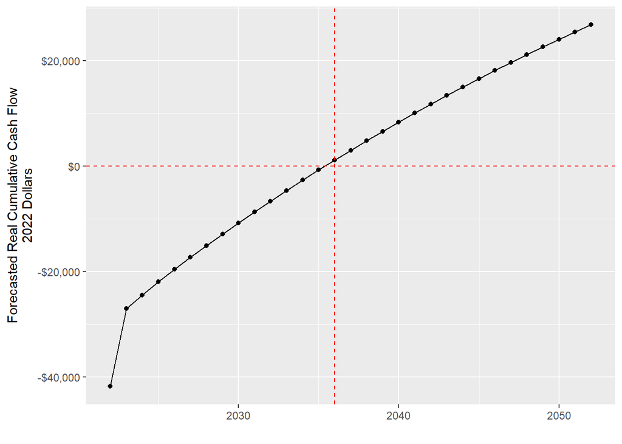

- Break Even Year: 2036
- 20 yr NPV: $11,181.08
- 25 yr NPV: $19,144.63